# Does Outside Money Win Elections?

*Super PAC spending and electoral outcomes in 2024 U.S. House races*

In 2024, Super PAC money flowed overwhelmingly toward close races and candidates who were already strong, not toward long shots. Candidates with Super PAC backing won **55%** of competitive races versus **41%** without it. But once incumbency and party are taken into account, outside money becomes a *secondary* predictor of victory, behind both. The clearest reading of the data: **Super PAC spending marks winners more than it makes them.**

## Background

Since the Supreme Court's *Citizens United* decision in 2010, Super PACs, independent expenditure-only committees that can raise and spend unlimited sums, have reshaped American elections. Outside spending on federal races reached a record **$4.5 billion** in 2024. Critics argue this gives wealthy donors outsized influence over who wins; defenders counter that the money simply chases candidates who are already viable. This report tests that question against the data.

The analysis is organized around four questions:

1. **Does Super PAC spending track electoral outcomes** — vote share and win/loss?
2. **Is it more important than a candidate's own fundraising?**
3. **Where does the money flow** — competitive or safe districts?
4. **Do Democrats and Republicans deploy it differently?**

**A note on causation.** Every relationship reported here is *associative, not causal*. Super PACs deliberately back candidates who are already competitive, so outside money and a candidate's underlying strength are entangled by design — no observational analysis can fully separate the two. Rather than overstate what the data can show, this report treats that limitation as part of the finding.

## The data

The analysis combines three public datasets covering the 2024 U.S. House:

- **MIT Election Lab — U.S. House returns (1976–2024).** Certified, district-level general-election results from the Harvard Dataverse. We use the 2024 general election to compute each district's two-party vote share, margin of victory, and winner.
- **FEC Independent Expenditures (2023–24 cycle).** Transaction-level records of money spent *for* (type 24E) and *against* (type 24A) federal candidates by outside groups. We keep only committees registered as Independent Expenditure-Only (committee type "O") — i.e. Super PACs — and aggregate their spending to the candidate level.
- **FEC Candidate Summary (2024).** Each candidate's total disbursements (their own campaign spending) and incumbency status, used both as a control and to answer the fundraising question.

### How competitiveness and spending are defined

**District competitiveness** is classified by the two-party margin of victory: **Toss-up** (0–5 points), **Competitive** (5–15), **Likely Safe** (15–30), and **Safe** (30+). This lets us ask not just *how much* outside money flows, but *where*, and whether it concentrates where races are genuinely in play.

**Super PAC spending** is the sum of independent expenditures by type-"O" committees on a given candidate, split into money spent *for* the candidate and money spent *against* them. Both directions matter: a candidate can be boosted by allies and attacked by opponents, and the two carry very different strategic logic.

## Building the analysis dataset

From the raw files we keep only 2024 general-election results, compute each district's vote share and margin, and classify competitiveness. On the finance side, we isolate independent expenditures (24E/24A) made by Super PACs and aggregate them per candidate into spending *for* and *against*. We then merge in each candidate's own disbursements and incumbency status. The result is one row per major-party candidate combining electoral outcome, outside spending, and self-funding, the single table behind every query and chart below. It is also written to a SQLite database so the relationships can be explored with SQL.

```
Total IE transactions: 77854
```

```
3073
```

## 1. Where does the money go?

If outside money were spread evenly, it would tell us little about strategy. It is not. The queries below trace Super PAC spending across district competitiveness, the highest-spending districts, and how concentrated the money is within each state.

|  | competitiveness | num_districts | avg_superpac | total_superpac |
| --- | --- | --- | --- | --- |
| 0 | Toss-up | 38 | 486711.94 | 162561788.0 |
| 1 | Competitive | 71 | 97913.38 | 59433424.0 |
| 2 | Safe | 205 | 69639.14 | 78761869.0 |
| 3 | Likely Safe | 122 | 48334.86 | 37894527.0 |

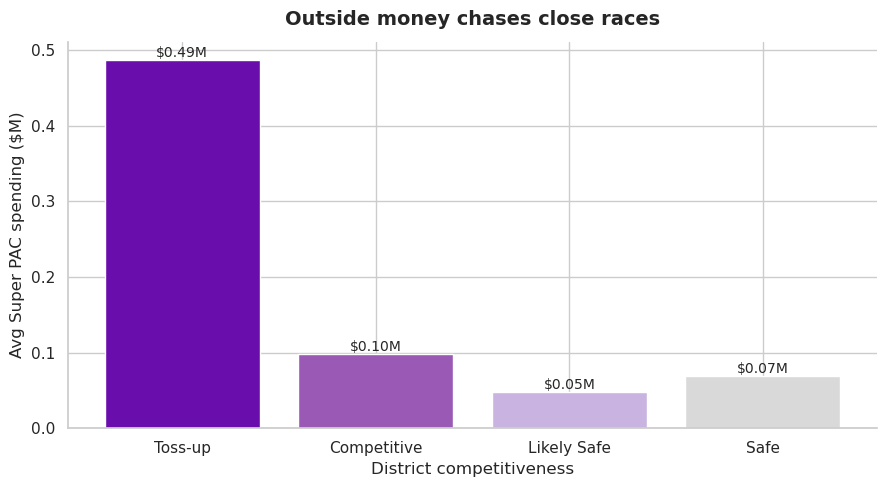

|  | CAND_OFFICE_ST | CAND_OFFICE_DISTRICT | competitiveness | winner_party | total_superpac |
| --- | --- | --- | --- | --- | --- |
| 0 | NY | 16.0 | Safe | DEMOCRAT | 16838475.0 |
| 1 | AK | 0.0 | Toss-up | REPUBLICAN | 15764631.0 |
| 2 | CA | 47.0 | Toss-up | DEMOCRAT | 14142592.0 |
| 3 | NY | 19.0 | Toss-up | DEMOCRAT | 11607172.0 |
| 4 | MO | 1.0 | Safe | DEMOCRAT | 11602210.0 |
| 5 | CA | 45.0 | Toss-up | DEMOCRAT | 8733395.0 |
| 6 | CO | 8.0 | Toss-up | REPUBLICAN | 8283007.0 |
| 7 | SC | 1.0 | Likely Safe | REPUBLICAN | 7382003.0 |
| 8 | NE | 2.0 | Toss-up | REPUBLICAN | 6994673.0 |
| 9 | VA | 7.0 | Toss-up | DEMOCRAT | 6920032.0 |

|  | group_label | num_districts | num_competitive | pct_competitive |
| --- | --- | --- | --- | --- |
| 0 | Above average spending | 130 | 73 | 56.2 |
| 1 | Below average spending | 306 | 36 | 11.8 |

|  | CAND_OFFICE_ST | CAND_OFFICE_DISTRICT | competitiveness | district_superpac | pct_of_state_total |
| --- | --- | --- | --- | --- | --- |
| 0 | AK | 0.0 | Toss-up | 15764631.0 | 100.0 |
| 1 | AL | 2.0 | Competitive | 3124498.0 | 52.7 |
| 2 | AL | 1.0 | Safe | 2731059.0 | 46.0 |
| 3 | AL | 7.0 | Likely Safe | 75926.0 | 1.3 |
| 4 | AL | 3.0 | Safe | 0.0 | 0.0 |
| 5 | AL | 4.0 | Safe | 0.0 | 0.0 |
| 6 | AL | 5.0 | Safe | 0.0 | 0.0 |
| 7 | AL | 6.0 | Safe | 0.0 | 0.0 |
| 8 | AR | 3.0 | Safe | 188992.0 | 54.5 |
| 9 | AR | 2.0 | Likely Safe | 156346.0 | 45.1 |
| 10 | AR | 4.0 | Safe | 1282.0 | 0.4 |
| 11 | AR | 1.0 | Safe | 0.0 | 0.0 |
| 12 | AZ | 6.0 | Toss-up | 5444398.0 | 39.2 |
| 13 | AZ | 1.0 | Toss-up | 4278232.0 | 30.8 |
| 14 | AZ | 3.0 | Safe | 2030345.0 | 14.6 |
| 15 | AZ | 8.0 | Competitive | 1857783.0 | 13.4 |
| 16 | AZ | 2.0 | Competitive | 249473.0 | 1.8 |
| 17 | AZ | 4.0 | Competitive | 41634.0 | 0.3 |
| 18 | AZ | 7.0 | Likely Safe | 682.0 | 0.0 |
| 19 | AZ | 5.0 | Likely Safe | 0.0 | 0.0 |

The money is concentrated even *within* states. In most states, one or two districts absorb nearly all of the outside dollars while safe seats receive little or nothing (in Alabama, two districts split 99% of the state's total). New York's 16th led the entire country at **$16.8M**, driven by a high-profile primary that pulled in national money. The picture is of Super PACs behaving like rational investors: **they put their money where the outcome is genuinely in doubt**.

## 2. Does the money win?

If outside money chases close races, the natural next question is whether it tips them. We begin with the simplest possible comparison, then control for the two factors that obviously confound it — **incumbency and party**.

```
Win rate by Super PAC support in competitive districts:
                       count  wins  win_rate  win_rate_pct
has_superpac_label
Has Super PAC Support    229   126     0.550          55.0
No Super PAC Support     595   242     0.407          40.7

Win rate by incumbency:
is_incumbent
0    0.368
1    0.814
Name: won, dtype: float64

Dataset size: 824
```

The raw gap is real: in competitive districts, candidates with any Super PAC support in their favor won **55%** of the time, versus **40.7%** for those with none — a 14-point spread that matters when margins are often in single digits.

But a raw gap cannot tell us whether the money *won* those races or simply *picked* candidates who were already likely to win. To separate the two, we model outcomes while holding incumbency and party constant.

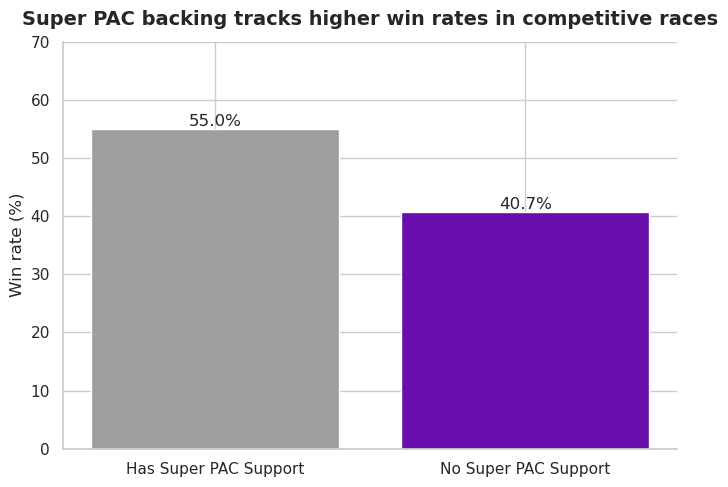

|  | CAND_PTY_AFFILIATION | competitiveness | outcome | num_candidates | avg_superpac_for | avg_superpac_against | avg_candidate_spending |
| --- | --- | --- | --- | --- | --- | --- | --- |
| 0 | DEM | Competitive | Loser | 102 | 32654.72 | 24844.53 | 670597.13 |
| 1 | DEM | Likely Safe | Loser | 204 | 1034.32 | 21.17 | 145890.74 |
| 2 | DEM | Safe | Loser | 197 | 31.35 | 507.90 | 139279.88 |
| 3 | DEM | Toss-up | Loser | 76 | 296250.14 | 268415.47 | 2209051.09 |
| 4 | DEM | Competitive | Winner | 162 | 132996.81 | 18829.51 | 1628036.56 |
| 5 | DEM | Likely Safe | Winner | 142 | 52942.19 | 6595.63 | 795021.24 |
| 6 | DEM | Safe | Winner | 340 | 64864.51 | 80110.87 | 1128745.06 |
| 7 | DEM | Toss-up | Winner | 83 | 358126.53 | 252686.25 | 2507692.57 |
| 8 | REP | Competitive | Loser | 235 | 12855.50 | 12338.09 | 309168.49 |
| 9 | REP | Likely Safe | Loser | 146 | 752.08 | 0.00 | 77864.89 |
| 10 | REP | Safe | Loser | 208 | 586.46 | 0.18 | 77800.78 |
| 11 | REP | Toss-up | Loser | 111 | 171545.02 | 119806.59 | 967099.43 |
| 12 | REP | Competitive | Winner | 108 | 130414.36 | 83031.41 | 1066285.87 |
| 13 | REP | Likely Safe | Winner | 292 | 52557.27 | 47151.74 | 749350.01 |
| 14 | REP | Safe | Winner | 386 | 39450.02 | 36306.42 | 873513.13 |
| 15 | REP | Toss-up | Winner | 64 | 234442.55 | 337584.20 | 1424738.27 |

Winners consistently drew more outside support than losers — Democratic winners averaged about **$111K** versus **$45K** for losing Democrats; Republican winners **$70K** versus **$31K**. But notice that the gap in candidates' *own* spending was even larger. That is the first hint that fundraising capacity, not outside money, is doing much of the work.

To pin this down, we fit two models on competitive districts only — Toss-ups and Competitive seats, where money is most likely to matter (Safe districts are excluded because their outcomes are driven by partisan lean, not spending). Each model uses six predictors: Super PAC spending for and against the candidate, the candidate's own spending, an indicator for any Super PAC support, party, and incumbency. Spending variables are log-transformed because campaign finance is heavily right-skewed.

```
=== Model 1: Linear Regression (predicting margin of victory) ===
R²: 0.143
RMSE: 8.007

Coefficients:
  log_superpac_for: 2.087
  log_superpac_against: -0.053
  log_TTL_DISB: 0.150
  has_superpac: -2.126
  party_dem: 1.395
  is_incumbent: 2.858
```

```
=== Model 2: Logistic Regression (predicting win/loss) ===
Accuracy: 0.667
              precision    recall  f1-score   support

           0       0.74      0.62      0.67        91
           1       0.61      0.73      0.66        74

    accuracy                           0.67       165
   macro avg       0.67      0.67      0.67       165
weighted avg       0.68      0.67      0.67       165


Coefficients:
  log_superpac_for: 0.534
  log_superpac_against: 0.075
  log_TTL_DISB: -0.052
  has_superpac: -0.599
  party_dem: 0.548
  is_incumbent: 0.828
```

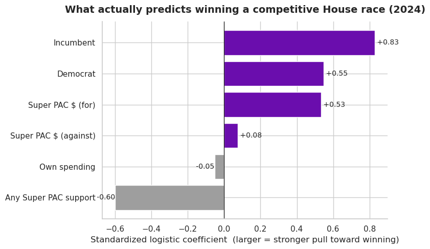

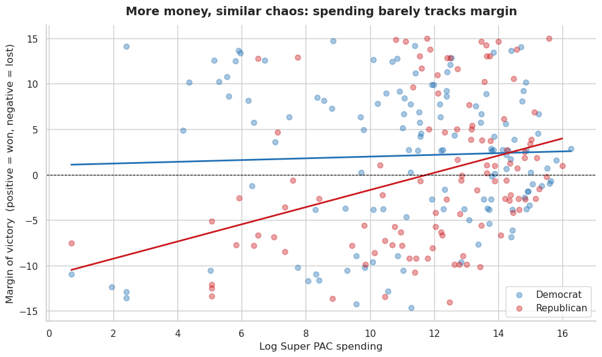

The scatter drives the point home. At every level of Super PAC spending, candidates land on both sides of the win/loss line — some win comfortably, others lose badly with similar backing. The wide dispersion is exactly what the low R² predicted: outside money alone is a weak guide to *how much* a candidate wins or loses by. The Republican trend line is steeper but starts lower (many GOP candidates in competitive seats received little support and lost), while the Democratic line is flatter and higher, reflecting Democrats' stronger baseline in 2024's competitive races.

## 3. Outside money, or the candidate's own war chest?

A common assumption is that Super PACs let candidates outsource their fundraising, that outside money substitutes for a strong campaign. The data say the opposite.

|  | superpac_support_level | num_candidates | avg_candidate_spending | avg_superpac | candidate_to_superpac_ratio |
| --- | --- | --- | --- | --- | --- |
| 0 | High Super PAC support | 137 | 4507559.34 | 2245989.85 | 2.01 |
| 1 | Low Super PAC support | 488 | 2263514.80 | 63509.17 | 35.64 |
| 2 | No Super PAC support | 2231 | 228501.30 | 0.00 | NaN |

|  | CAND_PTY_AFFILIATION | competitiveness | num_districts | avg_superpac | avg_candidate_spending | superpac_as_pct_of_candidate |
| --- | --- | --- | --- | --- | --- | --- |
| 0 | DEM | Toss-up | 38 | 588755.02 | 2364945.70 | 24.9 |
| 1 | DEM | Competitive | 71 | 115381.77 | 1258116.78 | 9.2 |
| 2 | DEM | Safe | 196 | 91988.57 | 765756.90 | 12.0 |
| 3 | DEM | Likely Safe | 120 | 25056.91 | 412296.90 | 6.1 |
| 4 | REP | Toss-up | 38 | 393998.51 | 1134464.49 | 34.7 |
| 5 | REP | Competitive | 71 | 84468.33 | 547561.13 | 15.4 |
| 6 | REP | Likely Safe | 122 | 66723.37 | 525521.64 | 12.7 |
| 7 | REP | Safe | 191 | 49434.35 | 594879.85 | 8.3 |

## 4. Democrats vs. Republicans

Both parties play the same game; they simply play it at different scales.

|  | CAND_PTY_AFFILIATION | num_candidates | total_superpac | avg_superpac |
| --- | --- | --- | --- | --- |
| 0 | DEM | 1328 | 182140390.0 | 137153.91 |
| 1 | REP | 1569 | 161250579.0 | 102772.84 |

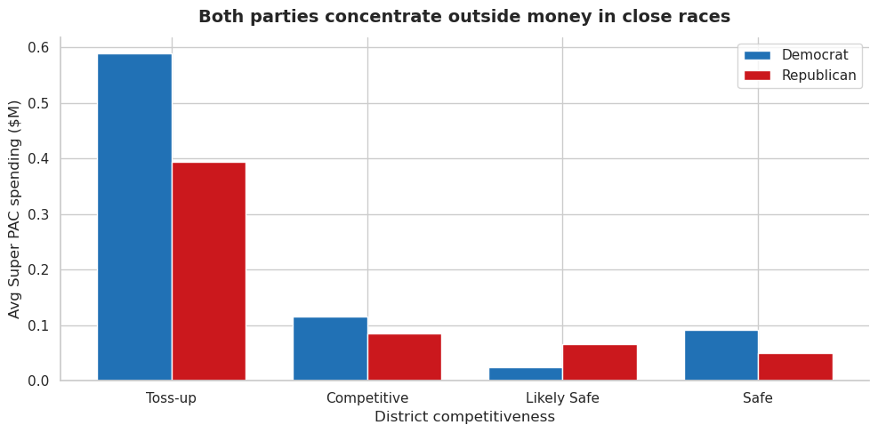

Democrats pulled in more Super PAC dollars in absolute terms in competitive districts. But Republicans were *relatively* more dependent on outside money, it made up a larger share of their total campaign resources (about **35%** of own spending in toss-ups, versus **25%** for Democrats). Both parties concentrate outside money in the same place: toss-up and competitive seats. The disagreement is over how much to lean on it, not where to aim it.

## Conclusion

Across every angle, the 2024 House data point the same way: **Super PAC money follows competitiveness and candidate strength rather than creating winners.**

Taken together, this is the **endogeneity problem** that runs through campaign-finance research: money flows to viable candidates, so its independent effect is genuinely difficult to isolate, and honest analysis should say so rather than overclaim.

**Next steps.** Add Cook Political Report PVI scores to control directly for district partisan lean — the key omitted variable here. Extend the analysis to the 2022 cycle to test whether the patterns hold across electoral environments. And examine primaries, where Super PAC spending may move less predictable outcomes than it does in general elections.

## Appendix

Supporting checks and additional queries behind the analysis above: data-quality validation, the spending distribution, and full summary tables.

### Data quality

The modeling dataset has no major missing-value problems — only `CAND_ICI` (incumbency) carried a handful of missing values, and every variable used in the models is complete. There are no problematic duplicate rows; numeric finance variables are stored as numbers, and the binary `won` and `is_incumbent` indicators are correctly encoded.

```
CAND_ID                 0
CAND_NAME               0
CAND_PTY_AFFILIATION    0
CAND_OFFICE_ST          0
CAND_OFFICE_DISTRICT    0
TTL_DISB                0
superpac_for            0
superpac_against        0
superpac_total          0
dem_pct                 0
rep_pct                 0
margin                  0
competitiveness         0
winner_party            0
CAND_ICI                5
is_incumbent            0
margin_outcome          0
won                     0
has_superpac            0
log_superpac_for        0
log_superpac_against    0
log_TTL_DISB            0
party_dem               0
has_superpac_label      0
dtype: int64
```

```
np.int64(0)
```

```
log_superpac_for        float64
log_superpac_against    float64
log_TTL_DISB            float64
won                       int64
is_incumbent              int64
dtype: object
```

### Spending distribution and outliers

Super PAC spending is heavily right-skewed, which is why we log-transform it before modeling. The extreme values are real, a handful of districts genuinely attract enormous sums, so they are kept rather than trimmed; they represent meaningful variation, not data errors.

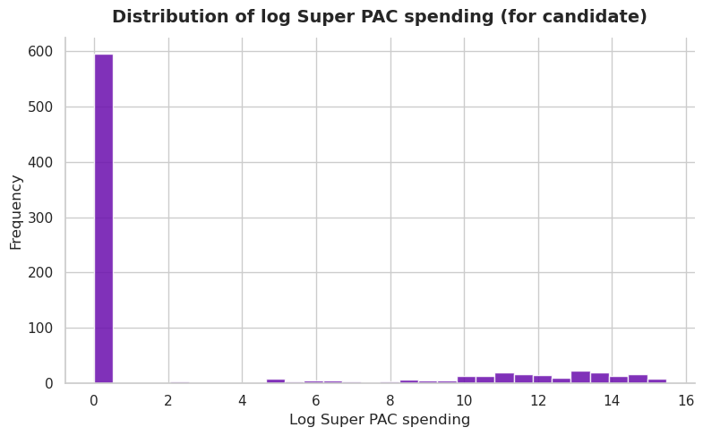

### Summary tables

|  | competitiveness | count | mean | median | min | max |
| --- | --- | --- | --- | --- | --- | --- |
| 0 | Competitive | 607 | 97913.38 | 0.0 | -14629.0 | 5765534.0 |
| 1 | Likely Safe | 784 | 48334.86 | 0.0 | -1357.0 | 4537946.0 |
| 2 | Safe | 1131 | 69639.14 | 0.0 | -21841.0 | 12110317.0 |
| 3 | Toss-up | 334 | 486711.94 | 0.0 | 0.0 | 11510742.0 |

|  | CAND_PTY_AFFILIATION | num_candidates | avg_superpac | median_superpac | avg_candidate_spending | median_candidate_spending |
| --- | --- | --- | --- | --- | --- | --- |
| 0 | DEM | 1306 | 139464.31 | 0.0 | 966336.43 | 41536.46 |
| 1 | REP | 1550 | 100974.98 | 0.0 | 625730.23 | 28622.72 |